# HW_Unsupervised Learning_Kelompok 3-ber7an

**KELOMPOK ber7an**:

- Indra Rivaldi Siregar
- Juldan Umbu Riada
- Nadya Audina S Kurnia
- Evinda Widyaningrum
- Himawan Jotama
- Zidni Fahra Andika
- Teguh Ferdianto

```python
import pandas as pd
import numpy as np
import matplotlib.pyplot as plt
import seaborn as sns
```

# Exploratory Data Analysis (EDA)

- Pastikan setiap kolom dataset memiliki tipe data yang tepat, tidak ada data kosong, bebas dari duplikat, dan berada di range value yang tepat.
- Keluarkan statistik kolom baik numerik maupun kategorikal, cari bentuk distribusi setiap kolom (numerik), dan jumlah baris untuk setiap unique value (kategorikal).
- Cari tahu apakah ada kolom-kolom yang berkorelasi kuat satu sama lain.
- A. Apakah ada kolom dengan tipe data kurang sesuai, atau nama kolom dan isinya kurang sesuai?
- B. Apakah ada kolom yang memiliki nilai kosong? Jika ada, apa saja?
- C. Apakah ada kolom yang memiliki nilai summary agak aneh? (min/mean/median/max/unique/top/freq)

```python
# read data
df = pd.read_csv('flight.csv')
```

## Informasi Umum Dataset

```python
df.info()
```

```
<class 'pandas.core.frame.DataFrame'>
RangeIndex: 62988 entries, 0 to 62987
Data columns (total 23 columns):
 #   Column             Non-Null Count  Dtype
---  ------             --------------  -----
 0   MEMBER_NO          62988 non-null  int64
 1   FFP_DATE           62988 non-null  object
 2   FIRST_FLIGHT_DATE  62988 non-null  object
 3   GENDER             62985 non-null  object
 4   FFP_TIER           62988 non-null  int64
 5   WORK_CITY          60719 non-null  object
 6   WORK_PROVINCE      59740 non-null  object
 7   WORK_COUNTRY       62962 non-null  object
 8   AGE                62568 non-null  float64
 9   LOAD_TIME          62988 non-null  object
 10  FLIGHT_COUNT       62988 non-null  int64
 11  BP_SUM             62988 non-null  int64
 12  SUM_YR_1           62437 non-null  float64
 13  SUM_YR_2           62850 non-null  float64
 14  SEG_KM_SUM         62988 non-null  int64
 15  LAST_FLIGHT_DATE   62988 non-null  object
 16  LAST_TO_END        62988 non-null  int64
 17  AVG_INTERVAL       62988 non-null  float64
 18  MAX_INTERVAL       62988 non-null  int64
 19  EXCHANGE_COUNT     62988 non-null  int64
 20  avg_discount       62988 non-null  float64
 21  Points_Sum         62988 non-null  int64
 22  Point_NotFlight    62988 non-null  int64
dtypes: float64(5), int64(10), object(8)
memory usage: 11.1+ MB
```

**HASIL PENGAMATAN:**

## Tipe Data (Numerical dan Categorical)

### Numerical Features

```python
cols = df.select_dtypes(include=['number'])
nums = cols.columns.tolist()
cols.sample(5)
```

|  | MEMBER_NO | FFP_TIER | AGE | FLIGHT_COUNT | BP_SUM | SUM_YR_1 | SUM_YR_2 | SEG_KM_SUM | LAST_TO_END | AVG_INTERVAL | MAX_INTERVAL | EXCHANGE_COUNT | avg_discount | Points_Sum | Point_NotFlight |
| --- | --- | --- | --- | --- | --- | --- | --- | --- | --- | --- | --- | --- | --- | --- | --- |
| 43434 | 51638 | 4 | 53.0 | 4 | 3625 | 2829.0 | 0.0 | 3522 | 565 | 1.333333 | 2 | 0 | 1.111670 | 3625 | 0 |
| 17038 | 9812 | 4 | 41.0 | 14 | 14561 | 9726.0 | 4140.0 | 18567 | 138 | 39.615385 | 139 | 0 | 0.768910 | 14561 | 0 |
| 55660 | 34793 | 4 | 32.0 | 4 | 1400 | 2343.0 | 0.0 | 2316 | 710 | 5.333333 | 8 | 0 | 0.825000 | 1400 | 0 |
| 48473 | 3527 | 4 | 46.0 | 2 | 1780 | 1722.0 | 0.0 | 4724 | 485 | 0.000000 | 0 | 0 | 0.636738 | 1780 | 0 |
| 10508 | 34122 | 4 | 29.0 | 9 | 22348 | 0.0 | 15547.0 | 27623 | 33 | 27.875000 | 67 | 0 | 0.767406 | 22348 | 0 |

### Non-Numerical Features

```python
cols = df.select_dtypes(exclude=['number', 'datetime'])
cats = cols.columns.tolist()
cols.sample(5)
```

|  | FFP_DATE | FIRST_FLIGHT_DATE | GENDER | WORK_CITY | WORK_PROVINCE | WORK_COUNTRY | LOAD_TIME | LAST_FLIGHT_DATE |
| --- | --- | --- | --- | --- | --- | --- | --- | --- |
| 29567 | 11/19/2010 | 3/21/2013 | Male | beijing | beijing | CN | 3/31/2014 | 3/3/2014 |
| 45560 | 1/16/2013 | 1/16/2013 | Male | chengdu | sichuan | CN | 3/31/2014 | 1/19/2013 |
| 50815 | 7/25/2012 | 10/6/2012 | Male | foshan | guangdong | CN | 3/31/2014 | 12/12/2013 |
| 9715 | 9/8/2012 | 11/4/2012 | Male | dalian | liaoning | CN | 3/31/2014 | 3/18/2014 |
| 46525 | 10/31/2009 | 2/11/2010 | Male | plainview | new york | US | 3/31/2014 | 3/9/2014 |

**HASIL PENGAMATAN:**

- Terdapat 15 kolom numerik.
- Terdapat 8 kolom kategorikal, di mana kolom `FFP_DATE`, `FIRST_FLIGHT_DATE`, `LOAD_TIME`, dan `LAST_FLIGHT_DATE` bisa diganti menjadi tipe data datetime.

## Checking Duplicated Data

Cek data duplikat di keseluruhan DataFrame.

```python
df.duplicated().sum()
```

```
0
```

**HASIL PENGAMATAN:**  
Tidak terdapat data yang duplikat pada tabel df.

## Kalkulasi Missing Value

```python
mv = df.isnull().sum()
tmv = df.isnull().count()

pmv = mv*100/tmv

mdf = pd.concat([mv, pmv], axis=1)
mdf.columns = ['Missing Value Total', 'Missing Value Percentage (%)']
mdf.sort_values(by='Missing Value Percentage (%)', ascending=False)
```

|  | Missing Value Total | Missing Value Percentage (%) |
| --- | --- | --- |
| WORK_PROVINCE | 3248 | 5.156538 |
| WORK_CITY | 2269 | 3.602273 |
| SUM_YR_1 | 551 | 0.874770 |
| AGE | 420 | 0.666794 |
| SUM_YR_2 | 138 | 0.219089 |
| WORK_COUNTRY | 26 | 0.041278 |
| GENDER | 3 | 0.004763 |
| MEMBER_NO | 0 | 0.000000 |
| LAST_FLIGHT_DATE | 0 | 0.000000 |
| Points_Sum | 0 | 0.000000 |
| avg_discount | 0 | 0.000000 |
| EXCHANGE_COUNT | 0 | 0.000000 |
| MAX_INTERVAL | 0 | 0.000000 |
| AVG_INTERVAL | 0 | 0.000000 |
| LAST_TO_END | 0 | 0.000000 |
| BP_SUM | 0 | 0.000000 |
| SEG_KM_SUM | 0 | 0.000000 |
| FFP_DATE | 0 | 0.000000 |
| FLIGHT_COUNT | 0 | 0.000000 |
| LOAD_TIME | 0 | 0.000000 |
| FFP_TIER | 0 | 0.000000 |
| FIRST_FLIGHT_DATE | 0 | 0.000000 |
| Point_NotFlight | 0 | 0.000000 |

**HASIL PENGAMATAN:**

- Terdapat 7 kolom yang memiliki missing value, yaitu: `GENDER`, `WORK_CITY`, `WORK_PROVINCE`, `WORK_COUNTRY`, `AGE`, `SUM_YR_1`, dan `SUM_YR_2`.
- Ketujuh kolom tersebut memiliki persentase missing value < 5.2% sehingga akan di-drop saat melakukan data pre-processing.

Kita dapat memanfaatkan library **missingno** untuk mengamati persebaran missing value di setiap kolom.

```python
# # Plot of Missing Values using matrix and heatmap missingno
# import missingno as msno
# msno.matrix(df);
```

## Statistik deskriptif kolom numerical

```python
df[nums].describe()
```

|  | MEMBER_NO | FFP_TIER | AGE | FLIGHT_COUNT | BP_SUM | SUM_YR_1 | SUM_YR_2 | SEG_KM_SUM | LAST_TO_END | AVG_INTERVAL | MAX_INTERVAL | EXCHANGE_COUNT | avg_discount | Points_Sum | Point_NotFlight |
| --- | --- | --- | --- | --- | --- | --- | --- | --- | --- | --- | --- | --- | --- | --- | --- |
| count | 62988.000000 | 62988.000000 | 62568.000000 | 62988.000000 | 62988.000000 | 62437.000000 | 62850.000000 | 62988.000000 | 62988.000000 | 62988.000000 | 62988.000000 | 62988.000000 | 62988.000000 | 62988.0000 | 62988.000000 |
| mean | 31494.500000 | 4.102162 | 42.476346 | 11.839414 | 10925.081254 | 5355.376064 | 5604.026014 | 17123.878691 | 176.120102 | 67.749788 | 166.033895 | 0.319775 | 0.721558 | 12545.7771 | 2.728155 |
| std | 18183.213715 | 0.373856 | 9.885915 | 14.049471 | 16339.486151 | 8109.450147 | 8703.364247 | 20960.844623 | 183.822223 | 77.517866 | 123.397180 | 1.136004 | 0.185427 | 20507.8167 | 7.364164 |
| min | 1.000000 | 4.000000 | 6.000000 | 2.000000 | 0.000000 | 0.000000 | 0.000000 | 368.000000 | 1.000000 | 0.000000 | 0.000000 | 0.000000 | 0.000000 | 0.0000 | 0.000000 |
| 25% | 15747.750000 | 4.000000 | 35.000000 | 3.000000 | 2518.000000 | 1003.000000 | 780.000000 | 4747.000000 | 29.000000 | 23.370370 | 79.000000 | 0.000000 | 0.611997 | 2775.0000 | 0.000000 |
| 50% | 31494.500000 | 4.000000 | 41.000000 | 7.000000 | 5700.000000 | 2800.000000 | 2773.000000 | 9994.000000 | 108.000000 | 44.666667 | 143.000000 | 0.000000 | 0.711856 | 6328.5000 | 0.000000 |
| 75% | 47241.250000 | 4.000000 | 48.000000 | 15.000000 | 12831.000000 | 6574.000000 | 6845.750000 | 21271.250000 | 268.000000 | 82.000000 | 228.000000 | 0.000000 | 0.809476 | 14302.5000 | 1.000000 |
| max | 62988.000000 | 6.000000 | 110.000000 | 213.000000 | 505308.000000 | 239560.000000 | 234188.000000 | 580717.000000 | 731.000000 | 728.000000 | 728.000000 | 46.000000 | 1.500000 | 985572.0000 | 140.000000 |

**HASIL PENGAMATAN:**

## Statistik deskriptif kolom categorical

```python
df[cats].describe()
```

|  | FFP_DATE | FIRST_FLIGHT_DATE | GENDER | WORK_CITY | WORK_PROVINCE | WORK_COUNTRY | LOAD_TIME | LAST_FLIGHT_DATE |
| --- | --- | --- | --- | --- | --- | --- | --- | --- |
| count | 62988 | 62988 | 62985 | 60719 | 59740 | 62962 | 62988 | 62988 |
| unique | 3068 | 3406 | 2 | 3234 | 1165 | 118 | 1 | 731 |
| top | 1/13/2011 | 2/16/2013 | Male | guangzhou | guangdong | CN | 3/31/2014 | 3/31/2014 |
| freq | 184 | 96 | 48134 | 9386 | 17509 | 57748 | 62988 | 959 |

**HASIL PENGAMATAN:**

- Kolom `FFP_DATE`, `FIRST_FLIGHT_DATE`, dan `LAST_FLIGHT_DATE` memiliki unique value > 700. Sebaiknya diganti menjadi datetime.
- Kolom `LOAD_TIME` hanya memiliki 1 unique value. Artinya, kolom ini bisa di-drop saja karena tidak bermanfaat dalam pemodelan.
- Sepertinya Kolom `Gender` tidak memiliki masalah, karena unique value-nya sudah berjumlah 2 dan dibuat dalam binary. Sepertinya ada sedikit ketimpangan jumlah data pada kolom ini.
- Kolom `WORK_CITY`, `WORK_PROVINCE`, dan `WORK_COUNTRY` memiliki kardinalitas yang tinggi.

Sekarang, kita coba tamplikan semua unique values dari setiap kolom. Hal ini perlu dilakukan untuk mengetahui apakah ada value yang tidak konsisten pada data kita.

```python
# Unique Values of Non-Numerical Features
for i in cats:
    total = df[i].nunique()
    print(f'unique value kolom {i}:', 'total:', total)
    print(f'{df[i].unique()}\n')
```

```
unique value kolom FFP_DATE: total: 3068
['11/2/2006' '2/19/2007' '2/1/2007' ... '5/3/2009' '1/25/2010' '5/19/2009']

unique value kolom FIRST_FLIGHT_DATE: total: 3406
['12/24/2008' '8/3/2007' '8/30/2007' ... '3/30/2014' '3/25/2014'
 '3/24/2014']

unique value kolom GENDER: total: 2
['Male' 'Female' nan]

unique value kolom WORK_CITY: total: 3234
['.' nan 'Los Angeles' ... 'BELLREGUARD' 'Danville' 'lingshui']

unique value kolom WORK_PROVINCE: total: 1165
['beijing' 'CA' 'guizhou' ... 'NOTARIO' 'TOPKPPI' 'JAWATIMUR']

unique value kolom WORK_COUNTRY: total: 118
['CN' 'US' 'FR' 'AN' 'JP' 'HK' 'MY' 'AU' 'NL' 'MX' 'CA' 'KR' 'PK' 'TH'
 'SG' 'BR' 'PE' 'AE' 'HN' 'PH' 'ID' 'MO' 'GN' 'FL' 'KH' nan 'TW' 'VN' 'DE'
 'IL' 'CH' 'PA' 'VT' 'EC' 'NG' 'BI' 'GT' 'BE' 'GL' 'NZ' 'FA' 'NI' 'KO'
 'CC' 'UV' 'MN' 'UK' 'AS' 'IT' 'OM' 'SE' 'BZ' 'IN' 'KZ' 'PT' 'NO' 'MS'
 'FI' 'UZ' 'NE' 'AT' 'AA' 'HU' 'CY' 'EG' 'MA' '中' 'ES' 'MZ' 'IR' 'SW' 'RE'
 'PS' 'KE' 'SN' 'BB' 'AZ' 'UA' 'LB' 'YE' 'GE' 'SI' 'KA' 'MV' 'RO' 'ZA'
 'DK' 'AB' 'CD' 'UY' 'CM' 'TK' 'AR' 'BN' 'PN' 'BD' '北' 'SU' 'RU' '沈' 'GU'
 'GB' 'ZW' 'PP' '芬' 'FO' 'IE' 'PR' 'BS' 'GH' 'SK' 'IA' 'cn' 'TR' 'LA' 'BG'
 'CL' 'CR' 'SA']

unique value kolom LOAD_TIME: total: 1
['3/31/2014']

unique value kolom LAST_FLIGHT_DATE: total: 731
['3/31/2014' '3/25/2014' '3/21/2014' '12/26/2013' '3/27/2014' '1/13/2014'
 '3/29/2014' '3/26/2014' '3/17/2014' '3/10/2014' '1/25/2014' '3/30/2014'
 '1/27/2014' '2/16/2014' '3/8/2014' '3/28/2014' '3/9/2014' '1/18/2014'
 '3/15/2014' '3/14/2014' '3/24/2014' '3/16/2014' '12/15/2013' '2/27/2014'
 '11/28/2013' '3/19/2014' '2/23/2014' '6/2/2013' '3/11/2014' '3/18/2014'
 '3/13/2014' '1/4/2014' '1/30/2014' '2/25/2014' '3/3/2014' '3/20/2014'
 '3/23/2014' '11/9/2013' '3/22/2014' '2/8/2014' '1/29/2014' '2/17/2014'
 '3/5/2014' '2/2/2014' '3/7/2014' '11/18/2013' '9/30/2013' '10/27/2013'
 '12/2/2013' '2/12/2014' '3/2/2014' '12/28/2013' '12/16/2013' '10/5/2013'
```

[output cut: 100 more lines]

```
 '5/2/2012' '7/14/2012' '9/14/2012' '6/29/2012' '11/9/2012' '7/20/2012'
 '6/5/2012' '1/4/2013' '6/22/2012' '10/22/2012' '8/22/2012' '8/10/2012'
 '6/9/2012' '6/14/2012' '7/11/2012' '10/4/2012' '10/21/2012' '8/23/2012'
 '9/17/2012' '8/31/2012' '5/1/2012' '7/22/2012' '9/3/2012' '10/1/2012'
 '9/9/2012' '7/16/2012' '9/7/2012' '6/21/2012' '8/9/2012' '1/10/2013'
 '6/6/2012' '8/2/2012' '7/2/2012' '7/5/2012' '7/1/2012' '4/8/2012'
 '5/29/2012' '6/12/2012' '4/23/2012' '5/4/2012' '7/4/2012' '4/12/2012'
 '5/23/2012' '5/3/2012' '5/24/2012' '6/25/2012' '5/20/2012' '6/8/2012'
 '5/8/2012' '5/16/2012' '4/18/2012' '7/31/2012' '4/22/2012' '7/12/2012'
 '4/28/2012' '8/8/2012' '4/17/2012' '6/15/2012' '6/13/2012' '5/18/2012'
 '5/26/2012' '5/22/2012' '6/20/2012' '4/10/2012' '4/3/2012' '6/3/2012'
 '6/30/2012' '6/1/2012' '4/27/2012' '5/12/2012' '4/26/2012' '4/13/2012'
 '4/16/2012' '4/20/2012' '4/19/2012' '5/13/2012' '5/9/2012' '4/9/2012'
 '4/7/2012' '4/14/2012' '4/5/2012' '7/10/2012' '4/15/2012' '4/6/2012'
 '4/1/2012' '4/4/2012']
```

**HASIL PENGAMATAN:**

- Sepertinya setiap unique value pada kolom `WORK_CITY` dan `WORK_PROVINCE` perlu dicek konsitensi penulisannya, karena ada value yang lowercase, capitalize, dan uppercase sehingga hal ini perlu disamakan.
- Terdapat unique value dengan penulisan mandarin pada kolom `WORK_COUNTRY` sehingga ini juga perlu diperbaiki. Contonya 芬, 沈, dan lainnya.
- Selain itu, sepertinya tidak ada masalah yang berarti.

## KDE Plot Kolom Numerical

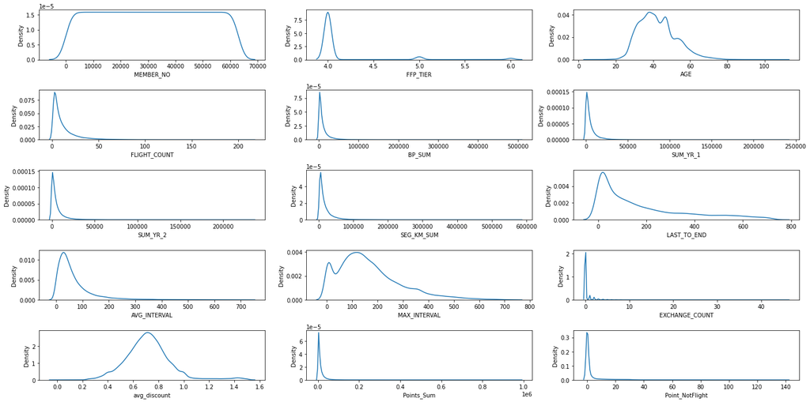

```python
plt.figure(figsize=(20,10))
for i in range(len(nums)):
    plt.subplot(5, 3, i+1)
    sns.kdeplot(x = df[nums[i]])
plt.tight_layout()
```

**HASIL PENGAMATAN:**

## Heatmap Correlation

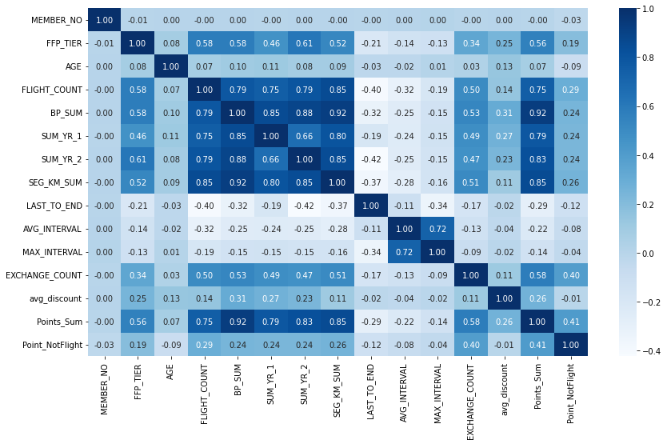

```python
plt.figure(figsize=(14, 8))
sns.heatmap(df.corr(), cmap='Blues', annot=True, fmt='.2f');
```

**HASIL PENGAMATAN:**

# Pre-processing

Fitur yang kami pilih untuk clustering yaitu:

- Recency (R) : 'LAST_TO_END'
- Frequency (F) : 'FLIGHT_COUNT'
- Monetary (M) : 'SEG_KM_SUM'

```python
features = ['LAST_TO_END', 'FLIGHT_COUNT', 'SEG_KM_SUM']

data = df[['MEMBER_NO', 'LAST_TO_END', 'FLIGHT_COUNT', 'SEG_KM_SUM']]
data
```

|  | MEMBER_NO | LAST_TO_END | FLIGHT_COUNT | SEG_KM_SUM |
| --- | --- | --- | --- | --- |
| 0 | 54993 | 1 | 210 | 580717 |
| 1 | 28065 | 7 | 140 | 293678 |
| 2 | 55106 | 11 | 135 | 283712 |
| 3 | 21189 | 97 | 23 | 281336 |
| 4 | 39546 | 5 | 152 | 309928 |
| ... | ... | ... | ... | ... |
| 62983 | 18375 | 297 | 2 | 1134 |
| 62984 | 36041 | 89 | 4 | 8016 |
| 62985 | 45690 | 29 | 2 | 2594 |
| 62986 | 61027 | 400 | 2 | 3934 |
| 62987 | 61340 | 403 | 2 | 4222 |

62988 rows × 4 columns

## Drop missing value

```python
# drop missing value kolom AGE
data = data.dropna()
data.shape
```

```
(62988, 4)
```

```python
data.isna().sum()
```

```
MEMBER_NO       0
LAST_TO_END     0
FLIGHT_COUNT    0
SEG_KM_SUM      0
dtype: int64
```

```python
data.dtypes
```

```
MEMBER_NO       int64
LAST_TO_END     int64
FLIGHT_COUNT    int64
SEG_KM_SUM      int64
dtype: object
```

## Handling Outlier

```
Boxplot Sebelum Handling Outlier
```

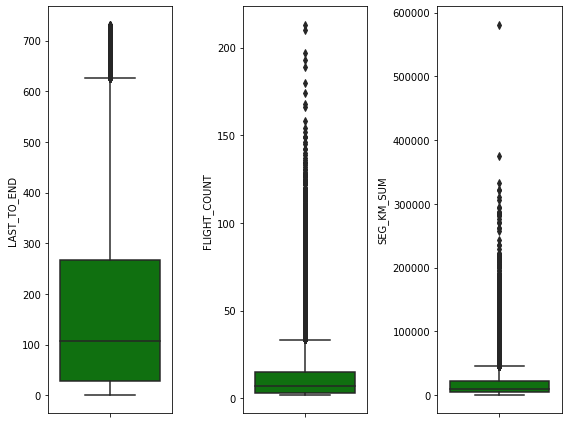

```python
# Boxplot sebelum handling outlier
features = ['LAST_TO_END','FLIGHT_COUNT','SEG_KM_SUM']

cols = features

print('Boxplot Sebelum Handling Outlier')
plt.figure(figsize=(8, 6))
for i in range(0, len(cols)):
    plt.subplot(1, len(cols), i+1)
    sns.boxplot(y=data[cols[i]],color='green',orient='v')
    plt.tight_layout()
```

```python
for col in cols:
    high_cut = data[col].quantile(q=0.99)
    low_cut= data[col].quantile(q=0.01)
    data.loc[data[col]>high_cut,col]=high_cut
    data.loc[data[col]<low_cut,col]=low_cut
```

```
Boxplot Setelah Handling Outlier
```

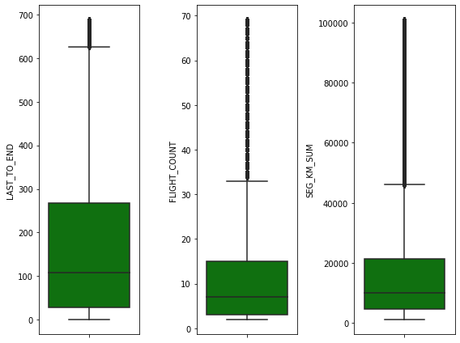

```python
# Boxplot setelah handling outlier
cols = features

print('Boxplot Setelah Handling Outlier')
plt.figure(figsize=(8, 6))
for i in range(0, len(cols)):
    plt.subplot(1, len(cols), i+1)
    sns.boxplot(y=data[cols[i]],color='green',orient='v')
    plt.tight_layout()
```

```
KDE PLOT
```

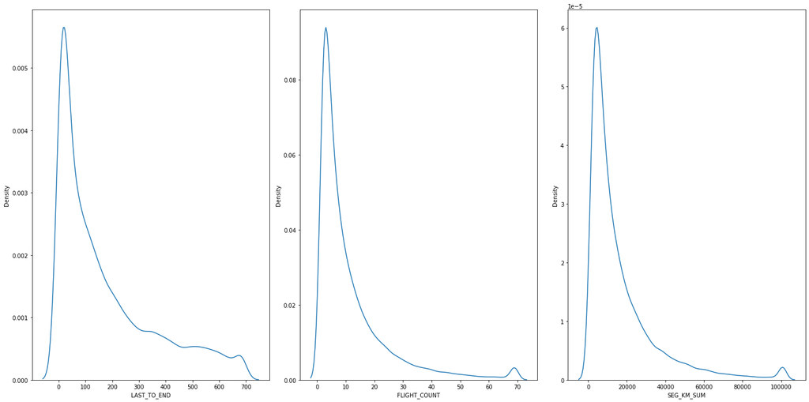

```python
# KDE Plot setelah handling outlier
print('KDE PLOT')
plt.figure(figsize=(20,10))
for i in range(len(cols)):
    plt.subplot(1, len(cols), i+1)
    sns.kdeplot(x = data[cols[i]])
plt.tight_layout()
```

## Pemilihan Fitur untuk Clustering

```python
data = data[['MEMBER_NO', 'LAST_TO_END','FLIGHT_COUNT','SEG_KM_SUM']]
data.head()
```

|  | MEMBER_NO | LAST_TO_END | FLIGHT_COUNT | SEG_KM_SUM |
| --- | --- | --- | --- | --- |
| 0 | 54993 | 1 | 69 | 100841.28 |
| 1 | 28065 | 7 | 69 | 100841.28 |
| 2 | 55106 | 11 | 69 | 100841.28 |
| 3 | 21189 | 97 | 23 | 100841.28 |
| 4 | 39546 | 5 | 69 | 100841.28 |

```python
data_= data.copy()
```

```python
df_lrfmc = data
df_lrfmc.columns = ['MEMBER_NO', 'recency','frequency','monetary']
df_lrfmc_drop = df_lrfmc[['recency','frequency','monetary']]
```

```python
df_lrfmc_drop.head()
```

|  | recency | frequency | monetary |
| --- | --- | --- | --- |
| 0 | 1 | 69 | 100841.28 |
| 1 | 7 | 69 | 100841.28 |
| 2 | 11 | 69 | 100841.28 |
| 3 | 97 | 23 | 100841.28 |
| 4 | 5 | 69 | 100841.28 |

```python
df_lrfmc_drop.describe()
```

|  | recency | frequency | monetary |
| --- | --- | --- | --- |
| count | 62988.000000 | 62988.000000 | 62988.000000 |
| mean | 175.932574 | 11.626945 | 16757.990417 |
| std | 183.287089 | 12.811748 | 18565.703613 |
| min | 1.000000 | 2.000000 | 1190.000000 |
| 25% | 29.000000 | 3.000000 | 4747.000000 |
| 50% | 108.000000 | 7.000000 | 9994.000000 |
| 75% | 268.000000 | 15.000000 | 21271.250000 |
| max | 687.000000 | 69.000000 | 100841.280000 |

```python
rfm_log = df_lrfmc_drop.copy()
```

```python
# handling outlier
cols= ['recency','frequency','monetary']
for col in cols:
    high_cut = rfm_log[col].quantile(q=0.99)
    low_cut=rfm_log[col].quantile(q=0.01)
    rfm_log.loc[rfm_log[col]>high_cut,col]=high_cut
    rfm_log.loc[rfm_log[col]<low_cut,col]=low_cut
```

## standarisasi

```python
from sklearn.preprocessing import MinMaxScaler

df_std = rfm_log
scale = MinMaxScaler()
kolom_all = [x for x in df_std.columns]
for kolom in kolom_all:
    df_std[kolom] = scale.fit_transform(np.array(df_std[kolom]).reshape(-1,1))

df_std.head()
```

|  | recency | frequency | monetary |
| --- | --- | --- | --- |
| 0 | 0.000000 | 1.000000 | 1.0 |
| 1 | 0.008746 | 1.000000 | 1.0 |
| 2 | 0.014577 | 1.000000 | 1.0 |
| 3 | 0.139942 | 0.313433 | 1.0 |
| 4 | 0.005831 | 1.000000 | 1.0 |

# Modelling

## Evaluasi dengan Elbow Method

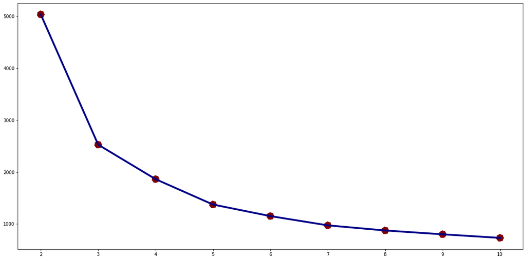

```python
from sklearn.cluster import KMeans
inertia = []

for i in range(2, 11):
    kmeans = KMeans(n_clusters=i, random_state=142)
    kmeans.fit(df_std)
    inertia.append(kmeans.inertia_)


plt.figure(figsize=(20, 10))
# plt.plot(inertia)

sns.lineplot(x=range(2, 11), y=inertia, color='#000087', linewidth = 4)
sns.scatterplot(x=range(2, 11), y=inertia, s=300, color='#800000',  linestyle='--')
```

```python
# from sklearn.metrics import silhouette_score

# for n_clusters in range(2,6):
#     clusterer = KMeans(n_clusters=n_clusters,init='k-means++', random_state=142).fit(data_std)
#     preds = clusterer.predict(data_std)

#     # TODO: Calculate the mean silhouette coefficient for the number of clusters chosen
#     score = silhouette_score(data_std, preds, metric='mahalanobis')
#     print ("For n_clusters = {}. The average silhouette_score is : {}".format(n_clusters, score))
```

## K-means Clustering dengan n_clusters=3

```python
kmeans = KMeans(n_clusters=3, random_state=0).fit(df_std)

df_data_std = pd.DataFrame(data=df_std, columns=list(data))

df_data_std['clusters'] = kmeans.labels_
data['clusters'] = kmeans.labels_

data.head(3)
```

|  | MEMBER_NO | recency | frequency | monetary | clusters |
| --- | --- | --- | --- | --- | --- |
| 0 | 54993 | 1 | 69 | 100841.28 | 2 |
| 1 | 28065 | 7 | 69 | 100841.28 | 2 |
| 2 | 55106 | 11 | 69 | 100841.28 | 2 |

## Visualisasi dengan PCA

```python
from sklearn.decomposition import PCA
pca = PCA(n_components=2)

pca.fit(df_std)
pcs = pca.transform(df_std)
```

```python
data_pca = pd.DataFrame(data = pcs, columns = ['PC 1', 'PC 2'])
data_pca
```

|  | PC 1 | PC 2 |
| --- | --- | --- |
| 0 | 1.004814 | 0.707517 |
| 1 | 0.998406 | 0.713467 |
| 2 | 0.994133 | 0.717433 |
| 3 | 0.563503 | 0.450713 |
| 4 | 1.000542 | 0.711483 |
| ... | ... | ... |
| 62983 | -0.273433 | -0.035444 |
| 62984 | -0.004431 | -0.190524 |
| 62985 | 0.019426 | -0.293829 |
| 62986 | -0.370543 | 0.081121 |
| 62987 | -0.372393 | 0.085610 |

62988 rows × 2 columns

```python
data_pca['clusters'] = data.clusters
```

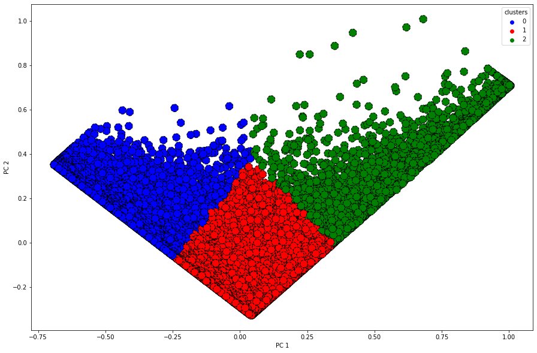

```python
fig, ax = plt.subplots(figsize=(15,10))

sns.scatterplot(
    x="PC 1", y="PC 2",
    hue="clusters",
    edgecolor='black',
    linestyle='--',
    data=data_pca,
    palette=['blue','red','green'],
    s=160,
    ax=ax
)
```

```python
hasil = data.drop('MEMBER_NO', axis=1)
hasil = hasil.groupby('clusters').agg(['mean', 'median'])
hasil
```

| clusters | recency mean | recency median | frequency mean | frequency median | monetary mean | monetary median |
| --- | --- | --- | --- | --- | --- | --- |
| 0 | 458.091854 | 441.0 | 4.083028 | 3.0 | 6338.430766 | 4530.5 |
| 1 | 96.346282 | 79.0 | 9.031883 | 8.0 | 12835.122442 | 10614.0 |
| 2 | 32.928571 | 16.0 | 38.182960 | 34.0 | 55066.595368 | 49154.5 |

Berdasarkan data di atas, terlihat bahwa nilai mean jauh lebih besar dibandingkan nilai mediannya, sehingga untuk membuat segmentasi customer kami memanfaatkan nilai median karena lebih merepresentasikan data di setiap cluster.

- 0 : Customer yang sudah lama tidak melakukan penerbangan dengan frekuensi dan pengeluaran yang paling rendah -> Low Value
- 1 : Customer yang jarang melakukan penerbangan tetapi pengeluarannya sedang -> Potential
- 2 : Customer yang sering melakukan penerbangan (frekuensi tertinggi) dan pengeluaran yang tinggi (monetary tinggi) -> Important